# practical_exercise_3, Methods 3, 2021, autumn semester

Mikkel Kristensen

04-10-2021

# Exercises and objectives

The objectives of the exercises of this assignment are:  
1) Download and organise the data and model and plot staircase responses based on fits of logistic functions  
2) Fit multilevel models for response times  
3) Fit multilevel models for count data

REMEMBER: In your report, make sure to include code that can reproduce the answers requested in the exercises below (**MAKE A KNITTED VERSION**)  
REMEMBER: This assignment will be part of your final portfolio

## Exercise 1

Go to https://osf.io/ecxsj/files/ and download the files associated with Experiment 2 (there should be 29).  
The data is associated with Experiment 2 of the article at the following DOI https://doi.org/10.1016/j.concog.2019.03.007

1. Put the data from all subjects into a single data frame

```r
temp_df <- list.files(pattern=".csv")
df <- lapply(temp_df, read.csv)

for (i in seq(df)){
  assign(paste0("df", i), df[[i]])
}
df_combcheck <- rbind(df1, df2, df3, df4,df5, df6,df7, df8,df9, df10,df11, df12,df13, df14,df15, df16, df17, df18,df19, df20,df21, df22,df23, df24,df25, df26,df27, df28, df29)

df_comb <- rbind(df1, df2, df3, df4,df5, df6,df7, df8,df9, df10,df11, df12,df13, df14,df15, df16, df17, df18,df19, df20,df21, df22,df23, df24,df25, df26,df27, df28, df29)
```

2. Describe the data and construct extra variables from the existing variables
   1. add a variable to the data frame and call it *correct* (have it be a *logical* variable). Assign a 1 to each row where the subject indicated the correct answer and a 0 to each row where the subject indicated the incorrect answer (**Hint:** the variable *obj.resp* indicates whether the subject answered “even”, *e* or “odd”, *o*, and the variable *target_type* indicates what was actually presented.

```r
o_e <- grepl("o", df_comb$obj.resp)

odd_even <- ifelse(df_comb$target.type=="odd", TRUE, FALSE)
odd_even_TorF <- odd_even==o_e

df_comb$correct <- ifelse(odd_even_TorF==TRUE, 1, 0)
```

[output not shown]

```r
#trial.type: There are two different trial types: "staircase" & "experiment"
class(df_comb$trial.type)
```

```
## [1] "character"
```

```r
#It is changed into a factor variabe
df_comb$trial.type <- as.factor(df_comb$trial.type)


#pas:

  #This is the rating scale, which is a scale used by each participant to rate their subjective opinion of their own performance on each trial. It is ordered on the following scale: A pas = 1 is the same as No Experience, a pas = 2 is Weak Glimpse, a pas = 3 is Almost Clear Experience and pas 4 = Clear Experience.
#This means the "pas" variable should be thought of as a categorical variable, as ordinal data.

class(df_comb$pas)
```

```
## [1] "integer"
```

```r
#We change it to factor data
df_comb$pas <- as.factor(df_comb$pas)


#trial:

  #This is the number of the trial for each subject across the two trial types staircase and experiment. In other words, each subject has a set of trials they go through for both trial types staircase and experiment.
class(df_comb$trial)
```

```
## [1] "integer"
```

```r
#The variable is currently an integer class, however, the trial variable is used for labeling. Thus, it is best to categorize it as a categorical variable and not as an integer. It is changed with the as.factor() function:
df_comb$trial <- as.factor(df_comb$trial)

#target.contrast:

  #The participants are presented with a target digit, and the target.contrast is a measure of the contrast between this digit and the background
class(df_comb$target.contrast)
```

```
## [1] "numeric"
```

```r
#It is continuous data and its class is "numeric", so it will not be changed.

#cue:

  #A cue is presented prior to the presentation of the stimulus. There are 36 different cues, and thus the cue variable functions a label of sorts. Therefore, it should be thought of as categorical (nominal) data.

#We change it to categorical
df_comb$cue <- as.factor(df_comb$cue)

#task:

  #There are three levels for this variable, which are "pairs", "quadruplets" and "singles". Again, one can argue that this is categorical (nominal) data.

#This is changed from "character" to a "factor":
df_comb$task <- as.factor(df_comb$task)

#target_type:

#This tells whether the digit (the target) is even or odd.
#It is changed to categorical data, as it represents discrete values (i.e. either/or).
df_comb$target.type <- as.factor(df_comb$target.type)

#rt.subj:

  #This is the subjective rating of one's performance. The scale used was the PAS scale.
class(df_comb$rt.subj)
```

```
## [1] "numeric"
```

```r
 #It is not changed from what it is, since it is a continuous data type and its class is numeric

#rt.obj:

  #This is the objective response time
class(df_comb$rt.obj)
```

```
## [1] "numeric"
```

```r
  #This is also a continuous data type and will remain as a numeric class

#obj.resp:

  #This is the objective response to whether the digit shown was even or odd.
class(df_comb$obj.resp)
```

```
## [1] "character"
```

```r
#It is changed from "character" to "factor"
df_comb$obj.resp <- as.factor(df_comb$obj.resp)

#subject:

  #This is the subject number for each participant. There were 29 participants (subjects) in total
class(df_comb$subject)
```

```
## [1] "integer"
```

```r
#It is changed into a factor variable
df_comb$subject <- as.factor(df_comb$subject)

#correct:

  #This variable tells us whether the participant correctly or incorrectly classified the digit they were shown as either even or odd.
class(df_comb$correct)
```

```
## [1] "numeric"
```

```r
#It is changed into a factor variable
df_comb$correct <- as.factor(df_comb$correct)
```

[output not shown]

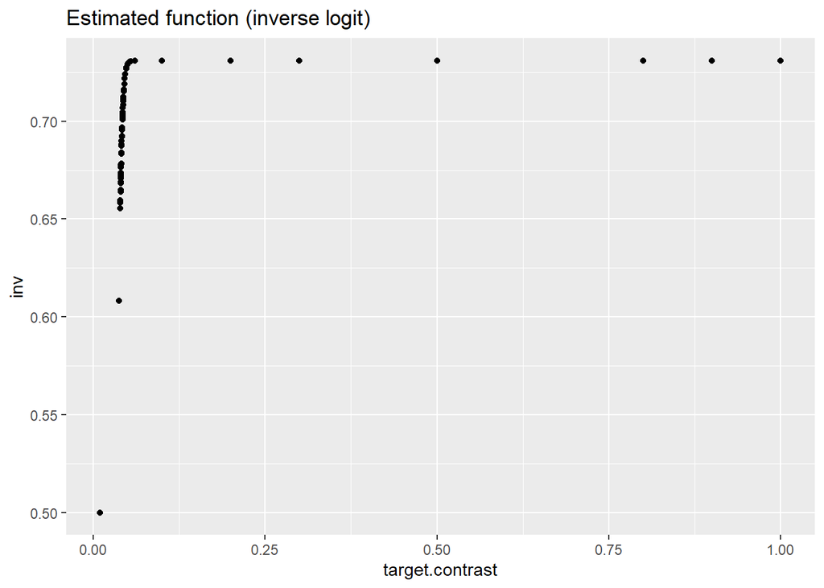

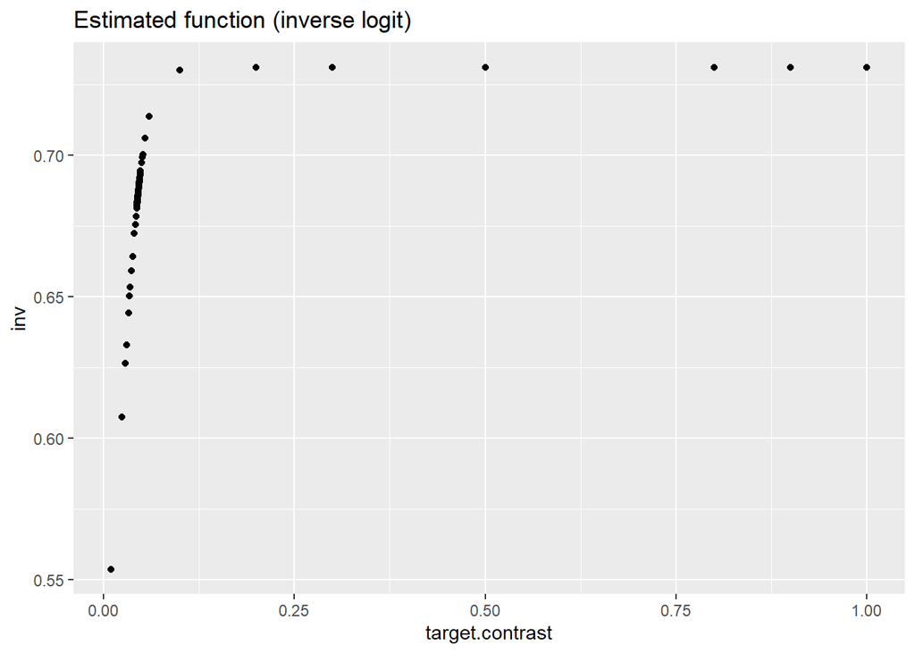

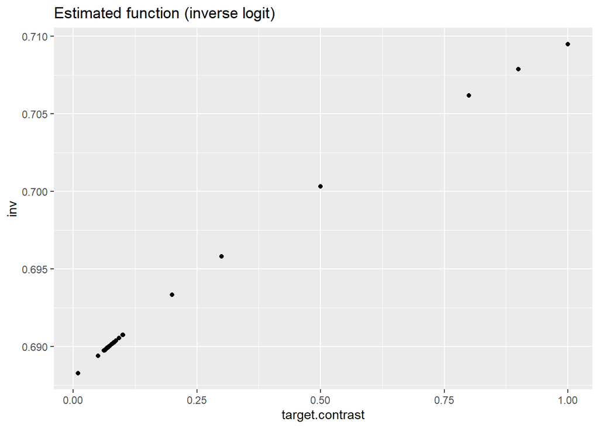

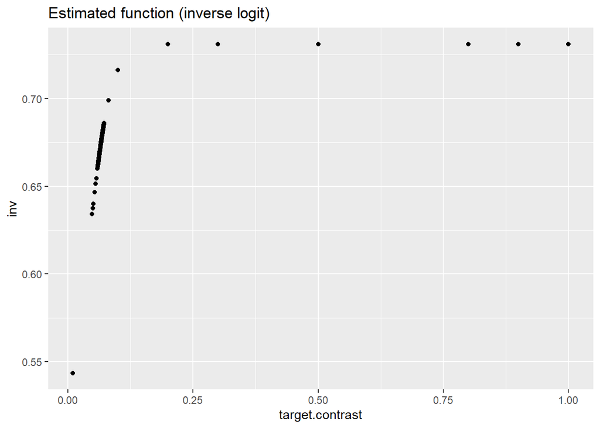

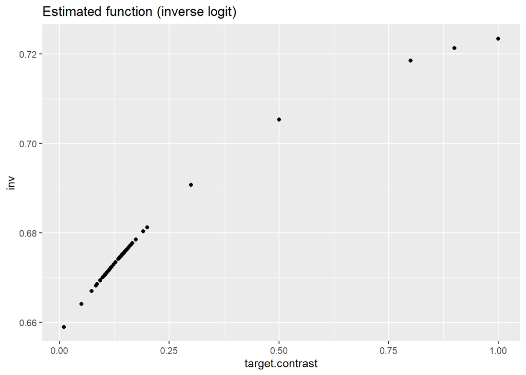

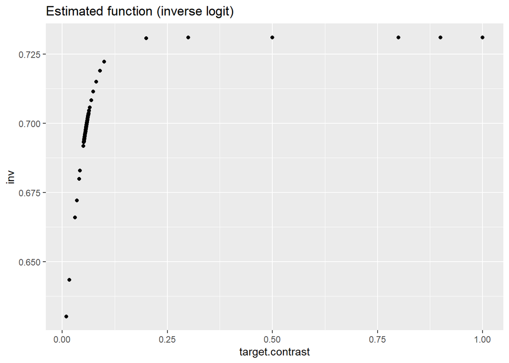

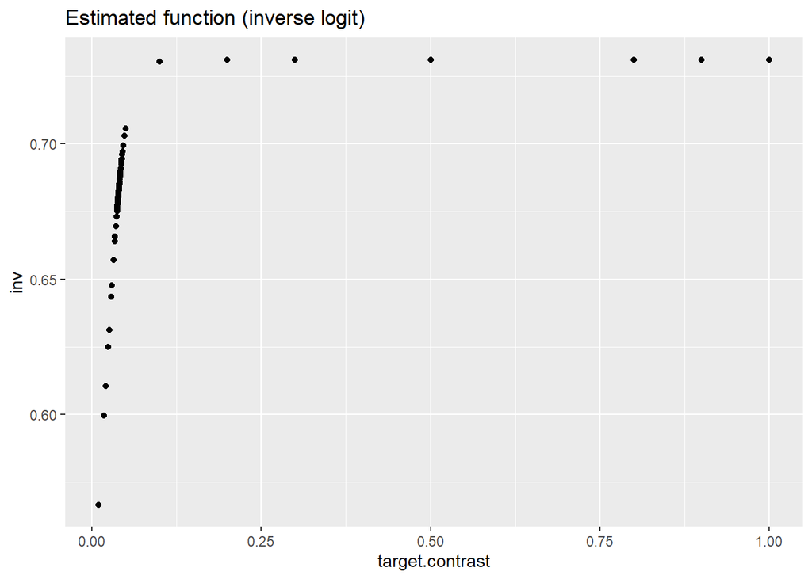

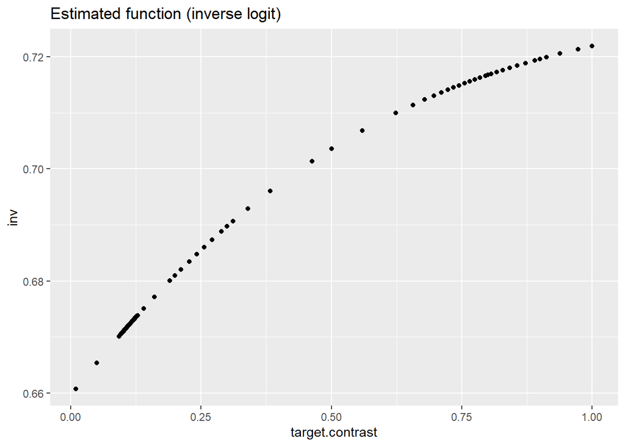

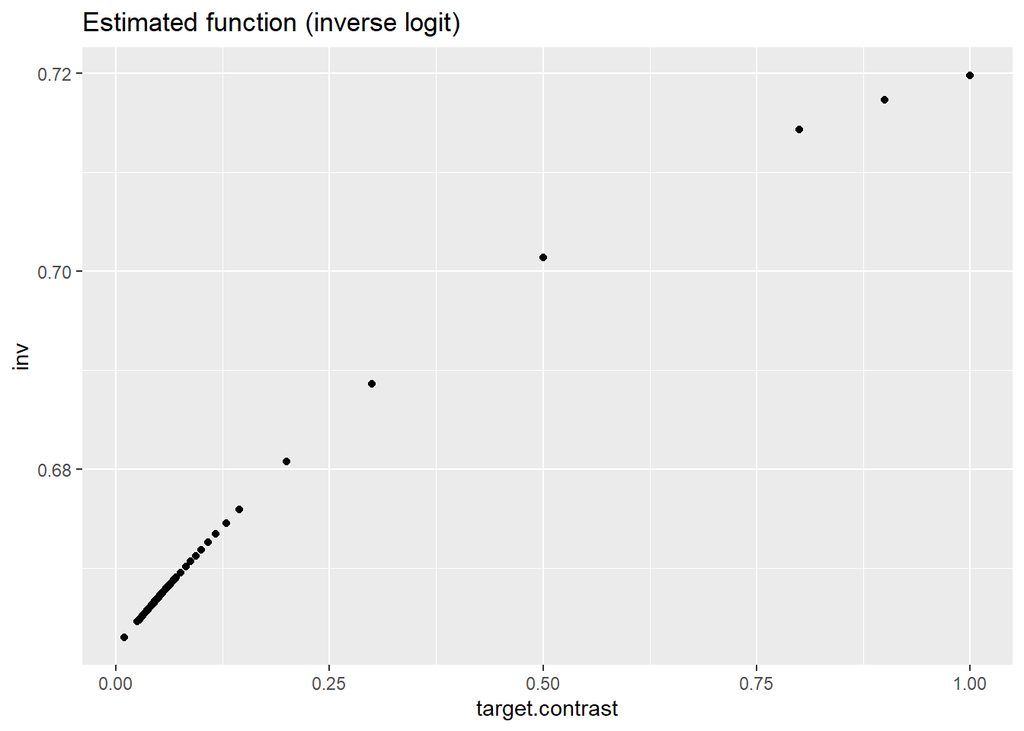

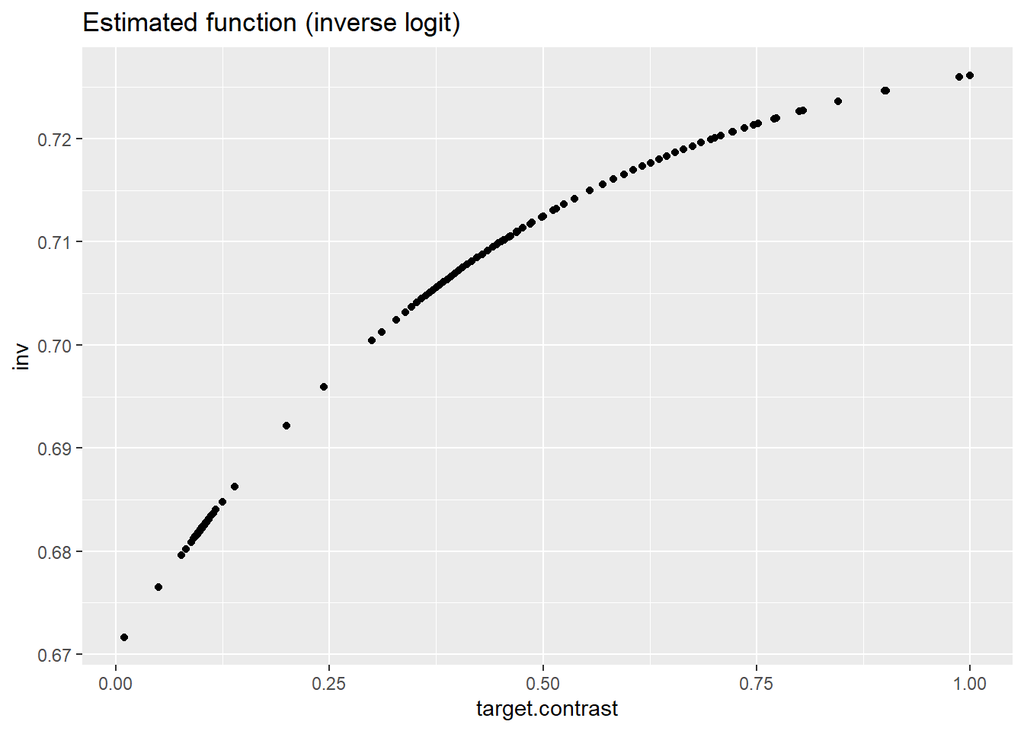

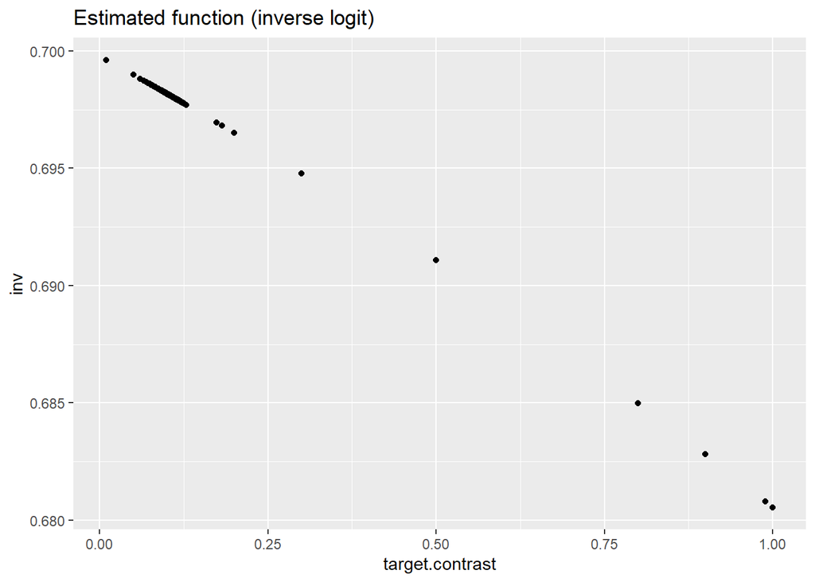

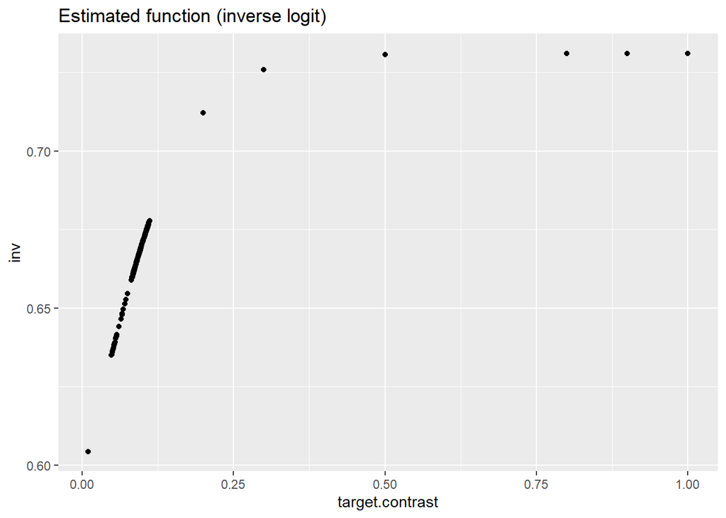

[17 more figures not shown]

```r
df_staircase <- df_comb[which(df_comb$trial.type=="staircase"), ]

#We will now create plots for each subject showing the estimated function based on the fitted values of a glm model. In order to obtain the estimated function, one needs to apply the inv.logit to the fitted valued (which we extract from the model once we fit the model).

inv.logit <- function(x) exp(x)/(1+exp(x))

for (i in 1:29){
  df_s <- df_staircase %>%
    filter(subject==i)

  model <- glm(correct~target.contrast, data=df_s, family="binomial")

  df_s <- df_s %>%
    mutate(inv=inv.logit(model$fitted.values))

  plot <- ggplot(df_s, aes(x=target.contrast, y=inv))+
    geom_point()+
    labs(title="Estimated function (inverse logit)")
  print(plot)

}
```

```r
#The plots do not seem to approximate an estimated function, so we might conclude that we do not have enough data to plot the logistic functions.
```

```
iv. on top of those plots, add the estimated functions (on the _target.contrast_ range from 0-1) for each subject based on partial pooling model (use `glmer` from the package `lme4`) where unique intercepts and slopes for _target.contrast_ are modelled for each _subject_
```

```r
library(lme4)
```

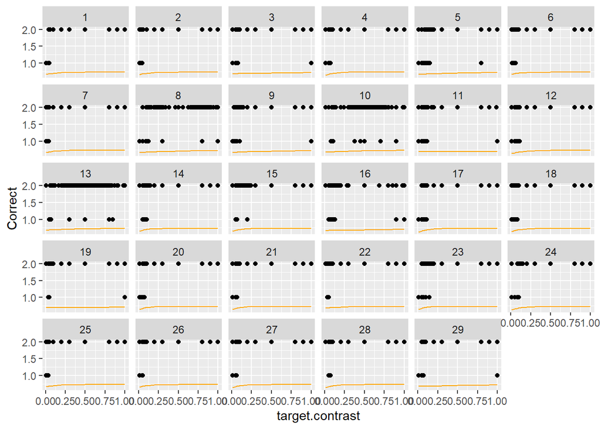

```r
df_staircase_prtl_pool <- glmer(correct~target.contrast+(1+target.contrast|subject), data=df_staircase, family="binomial")

df_staircase$fitted.values_ppool <- inv.logit(fitted(df_staircase_prtl_pool))

ggplot(df_staircase, aes(x=target.contrast, y = as.integer(correct)))+
  geom_point()+
  geom_line(aes(target.contrast, fitted.values_ppool), color="orange")+
  facet_wrap(~subject)+
  ylab("Correct")
```

```r
#Partial pooling plot for each subject
```

```
v. in your own words, describe how the partial pooling model allows for a better fit for each subject
```

```r
#The advantage of partial pooling is that it is able to account for variance in the data across multiple levels whilst not overstating the variation between the groups in the data as is the case with no-pooling models. In other words, complete pooling does not account for variation between groups in the data whereas no-pooling overstates the variation between groups. Partial pooling finds a midpoint between these two poles by pooling information from the fixed effects (complete pooling) and the random effects (no-pooling), such that partial pooling accounts for both general tendencies (via fixed effects) and also variation between groups in the data (via random effects).

#With regards to the specific plot created above, it is evident that there is a slight change in the plotting of the logistic function for each subject from the no-pooling plot created earlier, albeit the partial plot above does not fully capture the logistic function.
```

## Exercise 2

Now we **only** look at the *experiment* trials (*trial.type*)

```r
df_experiment <- df_comb[which(df_comb$trial.type=="experiment")
, ]
```

1. Pick four subjects and plot their Quantile-Quantile (Q-Q) plots for the residuals of their objective response times (*rt.obj*) based on a model where only intercept is modelled
   1. comment on these
   2. does a log-transformation of the response time data improve the Q-Q-plots?

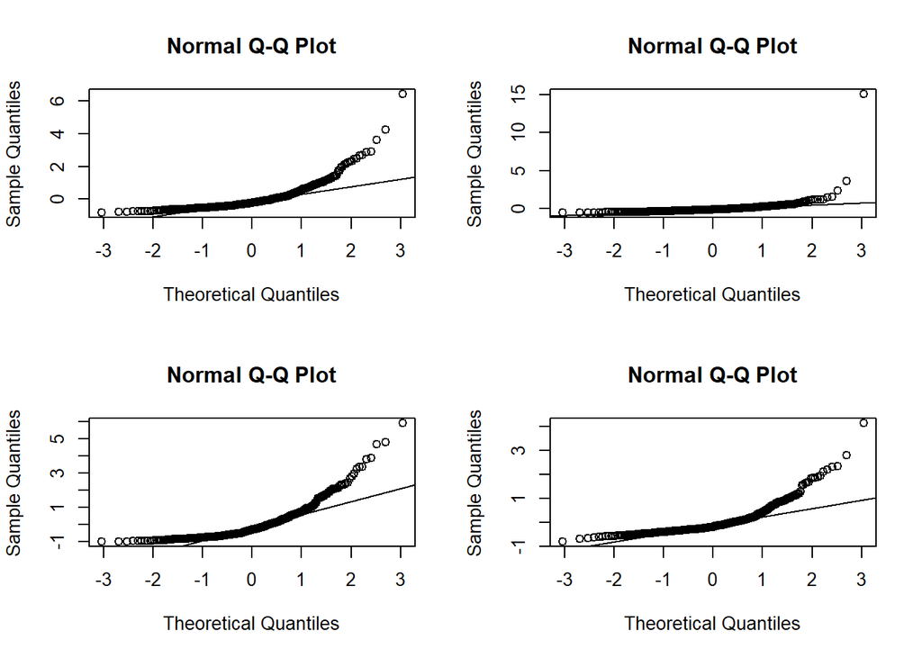

```r
#Perhaps change this one as well
df_experiment_subjects <- df_experiment[which(df_experiment$subject==c(4, 12, 19, 24)), ] #We pick four subjects

df_experiment_subject_4 <- df_experiment[which(df_experiment$subject==4), ]

model_int_subj_sub4 <- glm(rt.obj~1, data=df_experiment_subject_4)


df_experiment_subject_12 <- df_experiment[which(df_experiment$subject==12), ]

model_int_subj_sub12 <- glm(rt.obj~1, data=df_experiment_subject_12)


df_experiment_subject_19 <- df_experiment[which(df_experiment$subject==19), ]

model_int_subj_sub19 <- glm(rt.obj~1, data=df_experiment_subject_19)


df_experiment_subject_24 <- df_experiment[which(df_experiment$subject==24), ]

model_int_subj_sub24 <- glm(rt.obj~1, data=df_experiment_subject_24)

#We now look at the QQ-plots for all subjects
par(mfrow=c(2,2))
qqnorm(model_int_subj_sub4$residuals)
qqline(model_int_subj_sub4$residuals)

qqnorm(model_int_subj_sub12$residuals)
qqline(model_int_subj_sub12$residuals)


qqnorm(model_int_subj_sub19$residuals)
qqline(model_int_subj_sub19$residuals)

qqnorm(model_int_subj_sub24$residuals)
qqline(model_int_subj_sub24$residuals)
```

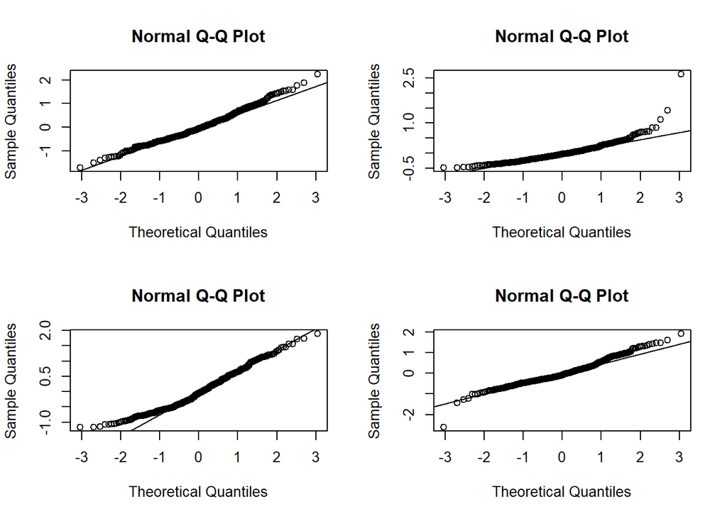

```r
#i.
#Comment on the residuals: They are a bit skewed to be honest, and might not indicate a normality of residuals at all.

#ii.
#We log-transform rt_obj for each subject
model_int_subj_log_sub4 <- glm(log(rt.obj)~1, data=df_experiment_subject_4)

model_int_subj_log_sub12 <- glm(log(rt.obj)~1, data=df_experiment_subject_12)

model_int_subj_log_sub19 <- glm(log(rt.obj)~1, data=df_experiment_subject_19)

model_int_subj_log_sub24 <- glm(log(rt.obj)~1, data=df_experiment_subject_24)

#We now look at the log-transformed residuals for each subject
par(mfrow=c(2,2))
qqnorm(model_int_subj_log_sub4$residuals)
qqline(model_int_subj_log_sub4$residuals)

qqnorm(model_int_subj_log_sub12$residuals)
qqline(model_int_subj_log_sub12$residuals)

qqnorm(model_int_subj_log_sub19$residuals)
qqline(model_int_subj_log_sub19$residuals)

qqnorm(model_int_subj_log_sub24$residuals)
qqline(model_int_subj_log_sub24$residuals)
```